# Tidying Case Study: Billboard Data

The billboard data includes the rankings for songs over time.

```python
import pandas as pd
import seaborn as sns
import matplotlib.pyplot as plt

billboard = pd.read_csv("https://raw.githubusercontent.com/hadley/tidy-data/master/data/billboard.csv", encoding="ISO-8859-1") # <-- I literally copied the "encoding" part from stackoverflow
```

Right now, weeks are stored as different variables, and the individual songs are observations. Let's instead consider the song's appearance each week as a separate observation. This takes the `week_number` from being an implicit to an explicit variable.

```python
billboard = pd.melt(
    billboard,
    id_vars=billboard.columns[:7],
    var_name="week",
    value_name="rank"
  )
billboard
```

|  | year | artist.inverted | track | time | genre | date.entered | date.peaked | week | rank |
| --- | --- | --- | --- | --- | --- | --- | --- | --- | --- |
| 0 | 2000 | Destiny's Child | Independent Women Part I | 3:38 | Rock | 2000-09-23 | 2000-11-18 | x1st.week | 78.0 |
| 1 | 2000 | Santana | Maria, Maria | 4:18 | Rock | 2000-02-12 | 2000-04-08 | x1st.week | 15.0 |
| 2 | 2000 | Savage Garden | I Knew I Loved You | 4:07 | Rock | 1999-10-23 | 2000-01-29 | x1st.week | 71.0 |
| 3 | 2000 | Madonna | Music | 3:45 | Rock | 2000-08-12 | 2000-09-16 | x1st.week | 41.0 |
| 4 | 2000 | Aguilera, Christina | Come On Over Baby (All I Want Is You) | 3:38 | Rock | 2000-08-05 | 2000-10-14 | x1st.week | 57.0 |
| ... | ... | ... | ... | ... | ... | ... | ... | ... | ... |
| 24087 | 2000 | Ghostface Killah | Cherchez LaGhost | 3:04 | R&B | 2000-08-05 | 2000-08-05 | x76th.week | NaN |
| 24088 | 2000 | Smith, Will | Freakin' It | 3:58 | Rap | 2000-02-12 | 2000-02-12 | x76th.week | NaN |
| 24089 | 2000 | Zombie Nation | Kernkraft 400 | 3:30 | Rock | 2000-09-02 | 2000-09-02 | x76th.week | NaN |
| 24090 | 2000 | Eastsidaz, The | Got Beef | 3:58 | Rap | 2000-07-01 | 2000-07-01 | x76th.week | NaN |
| 24091 | 2000 | Fragma | Toca's Miracle | 3:22 | R&B | 2000-10-28 | 2000-10-28 | x76th.week | NaN |

24092 rows × 9 columns

Let's fix the types. The week should be an integer, and the dates should be dates.

```python
billboard.dtypes
```

```
year                 int64
artist.inverted     object
track               object
time                object
genre               object
date.entered        object
date.peaked         object
week                object
rank               float64
dtype: object
```

```python
def parse_week(x):
    x = x.str.extract(r"([0-9]+)")
    return pd.to_numeric(x[0])

def minutes(time):
    parsed_time = pd.to_datetime(billboard["time"], format="%M:%S")
    ref_time = pd.to_datetime("00:00", format="%M:%S")
    return (parsed_time - ref_time).dt.total_seconds() / 60

billboard = (billboard.assign(
      week=lambda df: parse_week(df["week"]),
      entered=lambda df: pd.to_datetime(df["date.entered"]),
      peaked=lambda df: pd.to_datetime(df["date.peaked"]),
      minutes=lambda df: minutes(billboard["time"])
    ).dropna()
    .assign(
      rank=lambda df: df["rank"].astype(int),
      inverse_rank=lambda df: 100 - df["rank"]
    ))

billboard.dtypes
```

```
year                        int64
artist.inverted            object
track                      object
time                       object
genre                      object
date.entered               object
date.peaked                object
week                        int64
rank                        int64
entered            datetime64[ns]
peaked             datetime64[ns]
minutes                   float64
inverse_rank                int64
dtype: object
```

```python
billboard = billboard.sort_values(["year", "artist.inverted", "track", "week"])
billboard
```

|  | year | artist.inverted | track | time | genre | date.entered | date.peaked | week | rank | entered | peaked | minutes | inverse_rank |
| --- | --- | --- | --- | --- | --- | --- | --- | --- | --- | --- | --- | --- | --- |
| 246 | 2000 | 2 Pac | Baby Don't Cry (Keep Ya Head Up II) | 4:22 | Rap | 2000-02-26 | 2000-03-11 | 1 | 87 | 2000-02-26 | 2000-03-11 | 4.366667 | 13 |
| 563 | 2000 | 2 Pac | Baby Don't Cry (Keep Ya Head Up II) | 4:22 | Rap | 2000-02-26 | 2000-03-11 | 2 | 82 | 2000-02-26 | 2000-03-11 | 4.366667 | 18 |
| 880 | 2000 | 2 Pac | Baby Don't Cry (Keep Ya Head Up II) | 4:22 | Rap | 2000-02-26 | 2000-03-11 | 3 | 72 | 2000-02-26 | 2000-03-11 | 4.366667 | 28 |
| 1197 | 2000 | 2 Pac | Baby Don't Cry (Keep Ya Head Up II) | 4:22 | Rap | 2000-02-26 | 2000-03-11 | 4 | 77 | 2000-02-26 | 2000-03-11 | 4.366667 | 23 |
| 1514 | 2000 | 2 Pac | Baby Don't Cry (Keep Ya Head Up II) | 4:22 | Rap | 2000-02-26 | 2000-03-11 | 5 | 87 | 2000-02-26 | 2000-03-11 | 4.366667 | 13 |
| ... | ... | ... | ... | ... | ... | ... | ... | ... | ... | ... | ... | ... | ... |
| 10793 | 2000 | matchbox twenty | Bent | 4:12 | Rock | 2000-04-29 | 2000-07-22 | 35 | 33 | 2000-04-29 | 2000-07-22 | 4.200000 | 67 |
| 11110 | 2000 | matchbox twenty | Bent | 4:12 | Rock | 2000-04-29 | 2000-07-22 | 36 | 37 | 2000-04-29 | 2000-07-22 | 4.200000 | 63 |
| 11427 | 2000 | matchbox twenty | Bent | 4:12 | Rock | 2000-04-29 | 2000-07-22 | 37 | 38 | 2000-04-29 | 2000-07-22 | 4.200000 | 62 |
| 11744 | 2000 | matchbox twenty | Bent | 4:12 | Rock | 2000-04-29 | 2000-07-22 | 38 | 38 | 2000-04-29 | 2000-07-22 | 4.200000 | 62 |
| 12061 | 2000 | matchbox twenty | Bent | 4:12 | Rock | 2000-04-29 | 2000-07-22 | 39 | 48 | 2000-04-29 | 2000-07-22 | 4.200000 | 52 |

5307 rows × 13 columns

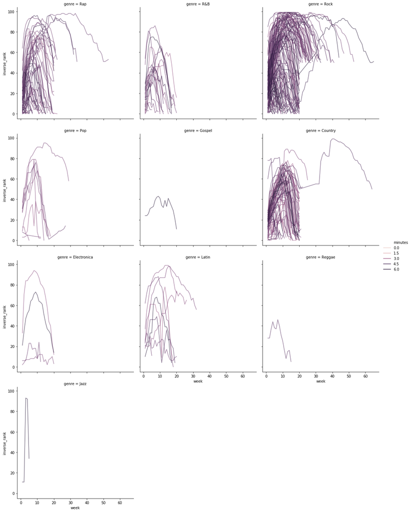

```python
plot = sns.relplot(
    x="week",
    y="inverse_rank",
    units="track",
    col="genre",
    kind="line",
    hue="minutes",
    hue_norm=plt.Normalize(1, 5),
    alpha=0.6,
    estimator=None,
    col_wrap=3,
    data=billboard
)

plot
```

The reason this was not too complicated to make was that we could refer directly to a `week` variable in the x-axis. This variable didn't exist before we tided the data!

A final consideration. Notice how the data are sort of redundant: We repeat the same information about the songs, each week they appear on the billboard.

```python
billboard
```

[output not shown]

This is another instance of the "sample ambiguity" problem. One way to resolve this is to split the data into two tables (which can be joined as needed),

- A `songs` table, giving attributes about each song
- A `ranks` table, providing the rankings of different songs across weeks.

First, let's make the songs table. The idea is to select the variables about songs that are constant across all weeks.

```python
song_cols = billboard.columns[:7]
songs = (billboard[song_cols].drop_duplicates()
          .sort_values(["genre", "artist.inverted", "track"])
          .assign(song_id=lambda df: df.reset_index().index))
songs.set_index("song_id").reset_index() # moves song_id to the front
```

|  | song_id | year | artist.inverted | track | time | genre | date.entered | date.peaked |
| --- | --- | --- | --- | --- | --- | --- | --- | --- |
| 0 | 0 | 2000 | Adkins, Trace | More | 3:05 | Country | 2000-04-29 | 2000-06-17 |
| 1 | 1 | 2000 | Allan, Gary | Smoke Rings In The Dark | 4:18 | Country | 2000-01-22 | 2000-02-05 |
| 2 | 2 | 2000 | Black, Clint | Been There | 5:28 | Country | 2000-02-19 | 2000-04-15 |
| 3 | 3 | 2000 | Brock, Chad | A Country Boy Can Survive | 3:54 | Country | 2000-01-01 | 2000-01-08 |
| 4 | 4 | 2000 | Brock, Chad | Yes! | 3:22 | Country | 2000-04-08 | 2000-07-01 |
| ... | ... | ... | ... | ... | ... | ... | ... | ... |
| 312 | 312 | 2000 | Wallflowers, The | Sleepwalker | 3:29 | Rock | 2000-10-28 | 2000-10-28 |
| 313 | 313 | 2000 | Westlife | Swear It Again | 4:07 | Rock | 2000-04-01 | 2000-07-01 |
| 314 | 314 | 2000 | Williams, Robbie | Angels | 3:56 | Rock | 1999-11-20 | 2000-01-22 |
| 315 | 315 | 2000 | Zombie Nation | Kernkraft 400 | 3:30 | Rock | 2000-09-02 | 2000-09-02 |
| 316 | 316 | 2000 | matchbox twenty | Bent | 4:12 | Rock | 2000-04-29 | 2000-07-22 |

317 rows × 8 columns

Now, we can create a table that tracks the ranks for songs over weeks.

```python
join_cols = ["year", "artist.inverted", "track"]
ranks = pd.merge(billboard, songs, on=join_cols)
ranks[["song_id", "week", "rank"]]
```

|  | song_id | week | rank |
| --- | --- | --- | --- |
| 0 | 121 | 1 | 87 |
| 1 | 121 | 2 | 82 |
| 2 | 121 | 3 | 72 |
| 3 | 121 | 4 | 77 |
| 4 | 121 | 5 | 87 |
| ... | ... | ... | ... |
| 5302 | 316 | 35 | 33 |
| 5303 | 316 | 36 | 37 |
| 5304 | 316 | 37 | 38 |
| 5305 | 316 | 38 | 38 |
| 5306 | 316 | 39 | 48 |

5307 rows × 3 columns